# Using the whalestrike package

Dan Kelley

2018-07-05

**Abstract.** This vignette explains the basics of using the whalestrike package to simulate the collision of a ship with a whale.

# 1 Introduction

This package solves Newton’s second law for a simple model of a ship colliding with a whale. This is a stripped-down model that does not attempt to simulate the biomechanical interactions that can be simulated in finite-element treatments such as that of Raymond (2007). The goal is to establish a convenient framework for rapid computation of impacts in a wide variety of conditions. The model runs quickly enough to keep up with mouse movements to select conditions, in a companion R shiny app. That app lets the user see the effects of changing contact area, ship speed, etc., as a way to build intuition for scenarios ranging from collision with a slow-moving fishing boat to collision with a thin dagger-board of a much swifter racing sailboat. Another advantage of the simple formulation is that it makes it easy to modify various dynamical and biomechanical parameters, to add new forces, and to explore a range of criteria for whale damage.

# 2 Examples

## 2.1 Overview plot

```r
library(whalestrike)
```

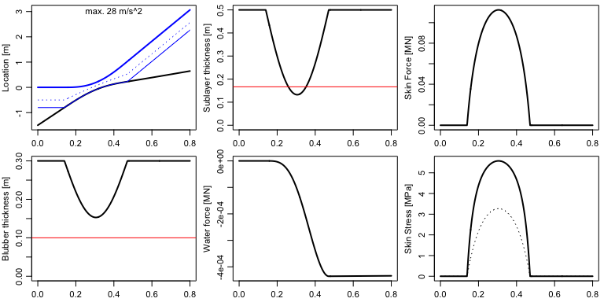

[figure not shown]

```r
t <- seq(0, 0.8, length.out=500)
state <- c(xs=-1.5, vs=5, xw=0, vw=0)

ms <- 20e3                             # ship mass
Ss <- 11.73*(2*1.58+4.63)              # ship wetted area (max)
impactWidth <- 0.5                     # impact width (guess, for pointed bow)
impactHeight <- 1.58                   # impact height (draft)
lw <- 10                               # whale length
mw <- whaleMassFromLength(lw)          # whale mass
Sw <- whaleAreaFromLength(lw,"wetted") # whale area
parms <- parameters(ms=ms, Ss=Ss, impactWidth=impactWidth, impactHeight=impactHeight,
                    lw=lw, mw=mw, Sw=Sw)
sol <- strike(t, state, parms)
par(mfcol=c(2, 3), mar=c(2, 3, 0.5, 0.5), mgp=c(2, 0.7, 0), cex=0.7)
plot(sol)
```